# 20 Years Apart: Understanding the Evolution of the NBA Playoffs by Clustering

## 1. Executive Summary

National Basketball Association (NBA) is one of the most popular professional sports leagues in United States and Canada, and is considered to be the premier men's professional basketball league in the world. It has two components, and the one which is held after every NBA regular season is the Playoffs, to determine the league's champion. With this, it is of interest to analyze how the players have evolved its playstyle from the start of the previous decade (2000) up to the current. We also want to see the difference between the performance of players across years in comparison with the recent playoffs.

To answer this problem, the researchers looked into clustering the players based on their game stat totals using the data scraped from [NBA website](https://www.basketball-reference.com/). The data includes only the NBA Playoffs starting from 2000 to 2019 and included only the first and last three years (of the scraped data) in the clustering.

K-means was used as the clustering algorithm since the dataset consists of mostly continuous variables with few features. Before the data was subjected to Kmeans, it was normalized first using the StandardScaler function from sklearn since the scales of the features largely differ from each other. After that, internal validation criteria particularly the Sum of Squares Distances to Centroids (SSE) was used to determine the optimal number of clusters for the dataset.

Results of the analysis showed that players of the NBA Playoffs can be grouped into 3 clusters: (1) Star players (2) Specialist / Role players (3) Players who rarely played during the playoffs. In addition, it was found out that there was a shift in the importance from defense to offense since in the early years, big men were given priority over shooters. However, in today's game, due to the rise of the Golden State Warriors and Stephen Curry, three (3) point shots were given more importance.

For future study, the researchers recommend to look at other decades and filter players with a certain threshold of number of games to eliminate the players that have small number of games played. They can also consider looking at the data of each player per possession or per 36 mins to better see the performance of each player.

## 2. Data Description

The dataset used in the study pertains to the Totals of the NBA Playoffs starting from 2000 to 2019 for a total of 20 years. This was scraped from https://www.basketball-reference.com/. Each row pertains to a unique player and each column pertains to the Stats measured per player. The data was divided into two groups: the first group ranges from 2000 to 2002 and the second group ranges from 2017 to 2019. The reason for the grouping is that we want to determine how the players evolve from the start of the previous decade (2000) up to now the current decade. There is also a separate analysis for the recent playoff (2019) to see the difference between the performance of players across decades in comparison with the recent playoffs. Listed below is the data dictionary for reference.

**Table 1. Data Dictionary**

[output not shown]

## 3. Data Processing

In this section, data is collected and translated into usable information. Data processing starts with scraping the data in its raw form from https://www.basketball-reference.com/ and converts it into a more readable format, giving it the form and context necessary to be interpreted by computers and utilized by the researchers. Scraped data is stored in a database named *dmwlab5*.

To start, we need to import first necessary libraries to be used in the succeeding sections.

```python
import numpy as np
import pandas as pd
import matplotlib.pyplot as plt
import seaborn as sns
import sqlite3
import requests
import json
from sklearn.metrics import calinski_harabaz_score, silhouette_score
from scipy.spatial.distance import euclidean, cityblock, cosine

from collections import Counter, OrderedDict
from math import pi

from sklearn.preprocessing import StandardScaler
from sklearn.cluster import KMeans
```

### 3.1. Data Scraping

As mentioned earlier, the data used in the study is scraped from the webisite and saved directly into the database. For this study, 20 tables were created in the database containing the NBA playoffs totals for all years starting from 2000 to 2019. The actual code for scraping is shown below:

```python
# This was comment out for the purpose of not overwriting the existing tables in the database
# years = [str(year) for year in range(1999, 2020)] # Scrape this list later
# for year in years:
#     url = 'https://www.basketball-reference.com/playoffs/NBA_' + year + '_totals.html'
#     resp = requests.get(url)
#     rsp_soup = BeautifulSoup(resp.text, 'lxml')
#     player_info = rsp_soup.select('.table_outer_container') # Selecting the table
#     df_pt = pd.read_html(str(player_info), index_col=0)[0]
#     df_pt.drop(labels='Rk', inplace=True) # Dropping header rows
#     df_pt.to_sql('year'+year, conn, if_exists='replace', index=False)
```

### 3.2. Connecting to the Database

```python
conn = sqlite3.connect('dmwlab5.db')
c = conn.cursor()
```

### 3.3. Selecting data from the Database

This is how we combine data for the first (2000-2002) and second group (2017-2019). Using the **UNION** function in SQL, we selected the data from 2000 to 2002 and combine them into one big dataset and named it df_decade2. Same is true for the data from 2017 to 2019 and saved it into df_decade1. The data for each year was also selected and saved into separate dataframe and this will be used in the plotting of performance across years later.

```python
df_decade1 = pd.read_sql('''SELECT * FROM YEAR2019 UNION
                            SELECT * FROM YEAR2018 UNION
                            SELECT * FROM YEAR2017
''', conn)

df_decade2 = pd.read_sql('''SELECT * FROM YEAR2000 UNION
                            SELECT * FROM YEAR2001 UNION
                            SELECT * FROM YEAR2002

''', conn)
```

```python
#Selecting data per year
df_year2019v1 = pd.read_sql('Select * from year2019', conn)
df_year2019 = pd.read_sql('Select * from year2019', conn)
df_year2018 = pd.read_sql('Select * from year2018', conn)
df_year2017 = pd.read_sql('Select * from year2017', conn)
df_year2016 = pd.read_sql('Select * from year2016', conn)
df_year2015 = pd.read_sql('Select * from year2015', conn)
df_year2014 = pd.read_sql('Select * from year2014', conn)
df_year2013 = pd.read_sql('Select * from year2013', conn)
df_year2012 = pd.read_sql('Select * from year2012', conn)
df_year2011 = pd.read_sql('Select * from year2011', conn)
df_year2010 = pd.read_sql('Select * from year2010', conn)
df_year2009 = pd.read_sql('Select * from year2009', conn)
df_year2008 = pd.read_sql('Select * from year2008', conn)
df_year2007 = pd.read_sql('Select * from year2007', conn)
df_year2006 = pd.read_sql('Select * from year2006', conn)
df_year2005 = pd.read_sql('Select * from year2005', conn)
df_year2004 = pd.read_sql('Select * from year2004', conn)
df_year2003 = pd.read_sql('Select * from year2003', conn)
df_year2002 = pd.read_sql('Select * from year2002', conn)
df_year2001 = pd.read_sql('Select * from year2001', conn)
df_year2000 = pd.read_sql('Select * from year2000', conn)
```

### 3.4. Data Cleaning

An important note on this is that each game stat in the dataset is on a per total basis of the playoffs. What we want to determine is the performance of the players per game because we might get the wrong idea if the games played was not considered. In order to account for this, we divide each game stat with the number of games played, and this calculation is shown in the function below together with the data cleaning.

```python
def data_cleaning(df):

    df.replace(np.nan, 0.0, inplace=True)

    df.iloc[:, 4:] = df.iloc[:, 4:].astype(float)
    df['Age'] = df['Age'].astype(float)

    df_decade_byplayer = df.groupby('Player').sum()

    df_decade_byplayer_dropped = df_decade_byplayer

    # Recalculating percentages
    df_decade_byplayer_dropped['FG%'] = df_decade_byplayer_dropped['FG']/df_decade_byplayer_dropped['FGA']
    df_decade_byplayer_dropped['3P%'] = df_decade_byplayer_dropped['3P']/df_decade_byplayer_dropped['3PA']
    df_decade_byplayer_dropped['2P%'] = df_decade_byplayer_dropped['2P']/df_decade_byplayer_dropped['2PA']
    df_decade_byplayer_dropped['FT%'] = df_decade_byplayer_dropped['FT']/df_decade_byplayer_dropped['FTA']

    # Calculating per game stats
    stat_per_game = df_decade_byplayer_dropped.columns.to_list()[2:17]
    for stat in stat_per_game:
        df_decade_byplayer_dropped[stat] = df_decade_byplayer_dropped[stat]/df_decade_byplayer_dropped['G']

    return df_decade_byplayer_dropped
```

```python
#Cleaning the first dataset
df_decade1_clean = data_cleaning(df_decade1)
```

```python
#Cleaning the second dataset
df_decade2_clean = data_cleaning(df_decade2)
```

```python
year_list = []
for i in range(20):
    year_list.append(2019-i)
```

```python
table_name = [df_year2000, df_year2001, df_year2002, df_year2003, df_year2004,
              df_year2005, df_year2006, df_year2007, df_year2008, df_year2009,
              df_year2010, df_year2011, df_year2012, df_year2013, df_year2014,
              df_year2015, df_year2016, df_year2017, df_year2018, df_year2019v1]

for i in table_name:
    i.iloc[:, 4:] = i.iloc[:, 4:].astype(float)
    i['Age'] = i['Age'].astype(float)
```

## 4. Exploratory Data Analysis

Before we proceed with the clustering proper, let's take a look at how the performance of players behave across years. Shown below are the plots of some relevant game stats that would give us insights about what to expect in the clustering.

### 4.1. Successful and Attempted Shots

First is the plot of successful and attempted shots across years. Successful shots include free throws, 2-point shot and 3-point shot that was successfully made by the player whereas the attempted shots are those that both include missed and successful shots.

```python
ThreeP = []
ThreePA = []
TwoP = []
TwoPA = []
FT = []
FTA = []

for i in table_name:
    ThreeP.append(np.nanmean(i['3P'].astype(float)))
    ThreePA.append(np.nanmean(i['3PA'].astype(float)))
    TwoP.append(np.nanmean(i['2P'].astype(float)))
    TwoPA.append(np.nanmean(i['2PA'].astype(float)))
    FT.append(np.nanmean(i['FT'].astype(float)))
    FTA.append(np.nanmean(i['FTA'].astype(float)))
```

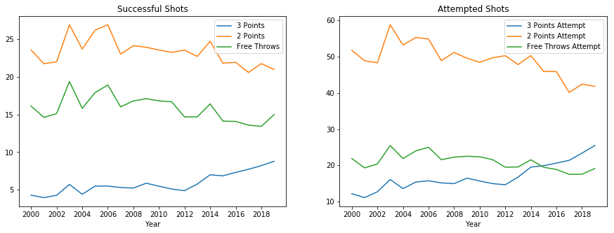

```python
fig, (ax, ax2) = plt.subplots(1, 2, figsize=(15, 5))

ax.plot(year_list[::-1], ThreeP, label='3 Points')
ax.plot(year_list[::-1], TwoP, label='2 Points')
ax.plot(year_list[::-1], FT, label='Free Throws')
ax.set_title('Successful Shots')
ax.set_xticks(np.arange(2000, 2020, 2))
ax.set_xlabel('Year')
ax.legend()

ax2.plot(year_list[::-1], ThreePA, label='3 Points Attempt')
ax2.plot(year_list[::-1], TwoPA, label='2 Points Attempt')
ax2.plot(year_list[::-1], FTA, label='Free Throws Attempt')
ax2.set_title('Attempted Shots')
ax2.set_xlabel('Year')
ax2.set_xticks(np.arange(2000, 2020, 2))
ax2.legend()
plt.show()
```

Based on the plots above, it can be seen that the trend for 2-point shot decreases for both Successful and Attempted shots while the trend for 3-point shot increases over time. For the Free throw shot, it also decreases for both successful and attempted shots. This just means that players tend to focus more on shooting 3-point shot starting from 2012 and lesser 2-point shot. This may be attributed to the era of Golden State Warriors and Stephen Curry which prioritizes 3-point shot rather than 2-point shot.

### 4.2. Assist and Rebounds

Another interesting game stat that we would want to see are the assists and rebounds of players. Assist is a good measurement of how players' teamwork is evident. Rebounds, on the otherhand, can either be offensive or defensive. This indicates the player's ability to get possession which might lead to higher chances of scoring.

```python
ORB = []
DRB = []
AST = []

for i in table_name:
    ORB.append(np.nanmean(i['ORB'].astype(float)))
    DRB.append(np.nanmean(i['DRB'].astype(float)))
    AST.append(np.nanmean(i['AST'].astype(float)))
```

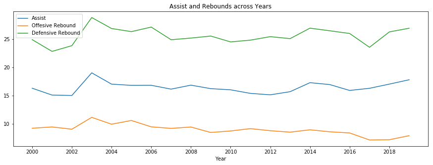

```python
fig, ax = plt.subplots(figsize=(15, 5))

ax.plot(year_list[::-1], AST, label='Assist')
ax.plot(year_list[::-1], ORB, label='Offesive Rebound')
ax.plot(year_list[::-1], DRB, label='Defensive Rebound')
ax.set_xticks(np.arange(2000, 2020, 2))
# ax.plot(year_list[::-1], PF, label = 'Personal Fouls')
ax.set_title('Assist and Rebounds across Years')
ax.set_xlabel('Year')
ax.legend()
plt.show()
```

Based on the plot, it can be seen that the trend for assist, offensive and defensive rebound does not vary much over time. This is because in winning the game, making a point is what matters most and these were just attacks not directly connected to scoring that is why its improvement has not given much importance.

### 4.3. Steals and Blocks

Steals and blocks play an important role in measuring the player's performance as it measures how defensive-oriented a player is. Steal is the ability of the player to get possession of the ball and preventing the opponent from shooting, and same is true for the block.

```python
STL = []
BLK = []

for i in table_name:
    STL.append(np.nanmean(i['STL'].astype(float)))
    BLK.append(np.nanmean(i['BLK'].astype(float)))
```

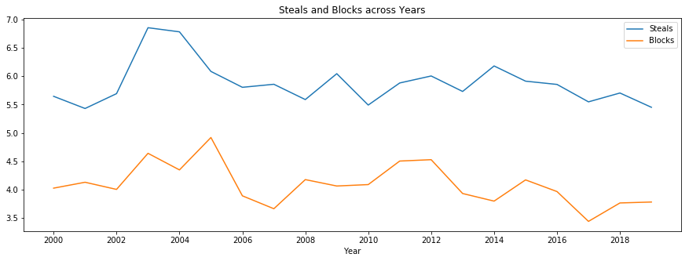

```python
fig, ax = plt.subplots(figsize=(15, 5))

ax.plot(year_list[::-1], STL, label='Steals')
ax.plot(year_list[::-1], BLK, label='Blocks')
# ax.plot(year_list[::-1], PF, label = 'Personal Fouls')
ax.set_title('Steals and Blocks across Years')
ax.set_xticks(np.arange(2000, 2020, 2))
ax.set_xlabel('Year')
ax.legend()
plt.show()
```

Just like the assists and rebounds, the trend for steals and blocks do not show a significant change across years. As what was mentioned earlier, more focus is given on the offensive part rather than defensive part.

### 4.4. Distribution plot of Relevant Features

One of the objectives of the study is to compare the performance of players across decades, using the first three years (from 2000-2002) and the last three years (from 2017-2019). In order to see the difference, a distribution plot for all the relevant features are shown below. Relevant feature is defined as the game stat that has a great impact on the player's performance.

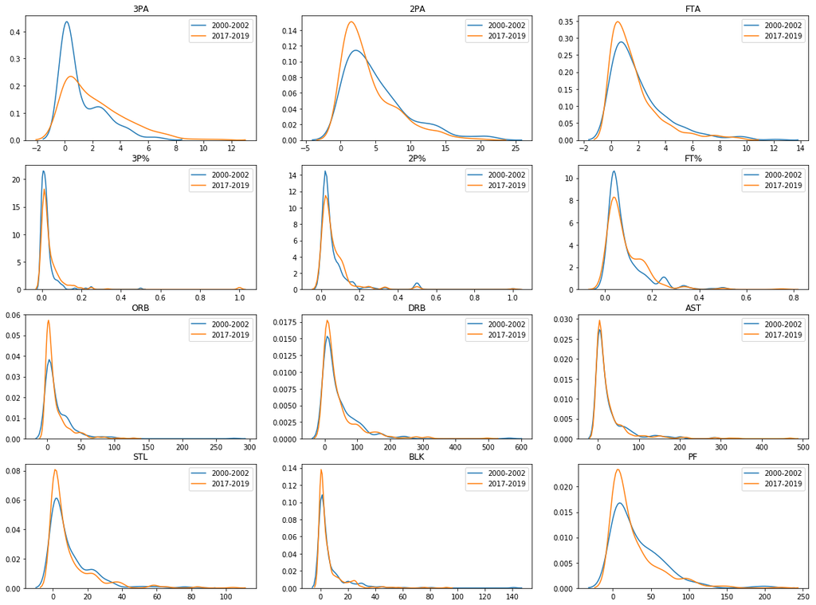

```python
fig, ax = plt.subplots(4, 3, figsize=(20,15))

sns.kdeplot(df_decade2_clean.loc[:, '3PA'], ax = ax[0,0], label='2000-2002')
sns.kdeplot(df_decade1_clean.loc[:, '3PA'], ax = ax[0,0], label='2017-2019')
# sns.kdeplot(df_year2019.loc[:, '3PA'], ax = ax[0,0], label='2019')
ax[0,0].set_title('3PA')
ax[0,0].legend()

sns.kdeplot(df_decade2_clean.loc[:, '2PA'], ax = ax[0,1], label='2000-2002')
sns.kdeplot(df_decade1_clean.loc[:, '2PA'], ax = ax[0,1], label='2017-2019')
# sns.kdeplot(df_year2019.loc[:, '2PA'], ax = ax[0,1], label='2019')
ax[0,1].legend()
ax[0,1].set_title('2PA')

sns.kdeplot(df_decade2_clean.loc[:, 'FTA'], ax = ax[0,2], label='2000-2002')
sns.kdeplot(df_decade1_clean.loc[:, 'FTA'], ax = ax[0,2], label='2017-2019')
# sns.kdeplot(df_year2019.loc[:, 'FTA'], ax = ax[0,2], label='2019')
ax[0,2].legend()
ax[0,2].set_title('FTA')

sns.kdeplot(df_decade2_clean.loc[:, '3P%'], ax = ax[1,0], label='2000-2002')
sns.kdeplot(df_decade1_clean.loc[:, '3P%'], ax = ax[1,0], label='2017-2019')
# sns.kdeplot(df_year2019.loc[:, '3P%'], ax = ax[1,0], label='2019')
ax[1,0].legend()
ax[1,0].set_title('3P%')

sns.kdeplot(df_decade2_clean.loc[:, '2P%'], ax = ax[1,1], label='2000-2002')
sns.kdeplot(df_decade1_clean.loc[:, '2P%'], ax = ax[1,1], label='2017-2019')
# sns.kdeplot(df_year2019.loc[:, '2P%'], ax = ax[1,1], label='2019')
ax[1,1].legend()
ax[1,1].set_title('2P%')

sns.kdeplot(df_decade2_clean.loc[:, 'FT%'], ax = ax[1,2], label='2000-2002')
sns.kdeplot(df_decade1_clean.loc[:, 'FT%'], ax = ax[1,2], label='2017-2019')
# sns.kdeplot(df_year2019.loc[:, 'FT%'], ax = ax[1,2], label='2019')
ax[1,2].legend()
ax[1,2].set_title('FT%')

sns.kdeplot(df_decade2_clean.loc[:, 'ORB'], ax = ax[2,0], label='2000-2002')
sns.kdeplot(df_decade1_clean.loc[:, 'ORB'], ax = ax[2,0], label='2017-2019')
# sns.kdeplot(df_year2019.loc[:, 'ORB'], ax = ax[2,0], label='2019')
ax[2,0].legend()
ax[2,0].set_title('ORB')

sns.kdeplot(df_decade2_clean.loc[:, 'DRB'], ax = ax[2,1], label='2000-2002')
sns.kdeplot(df_decade1_clean.loc[:, 'DRB'], ax = ax[2,1], label='2017-2019')
# sns.kdeplot(df_year2019.loc[:, 'DRB'], ax = ax[2,1], label='2019')
ax[2,1].legend()
ax[2,1].set_title('DRB')

sns.kdeplot(df_decade2_clean.loc[:, 'AST'], ax = ax[2,2], label='2000-2002')
sns.kdeplot(df_decade1_clean.loc[:, 'AST'], ax = ax[2,2], label='2017-2019')
# sns.kdeplot(df_year2019.loc[:, 'AST'], ax = ax[2,2], label='2019')
ax[2,2].legend()
ax[2,2].set_title('AST')

sns.kdeplot(df_decade2_clean.loc[:, 'STL'], ax = ax[3,0], label='2000-2002')
sns.kdeplot(df_decade1_clean.loc[:, 'STL'], ax = ax[3,0], label='2017-2019')
# sns.kdeplot(df_year2019.loc[:, 'STL'], ax = ax[3,0], label='2019')
ax[3,0].legend()
ax[3,0].set_title('STL')

sns.kdeplot(df_decade2_clean.loc[:, 'BLK'], ax = ax[3,1], label='2000-2002')
sns.kdeplot(df_decade1_clean.loc[:, 'BLK'], ax = ax[3,1], label='2017-2019')
# sns.kdeplot(df_year2019.loc[:, 'BLK'], ax = ax[3,0], label='2019')
ax[3,1].legend()
ax[3,1].set_title('BLK')

sns.kdeplot(df_decade2_clean.loc[:, 'PF'], ax = ax[3,2], label='2000-2002')
sns.kdeplot(df_decade1_clean.loc[:, 'PF'], ax = ax[3,2], label='2017-2019')
# sns.kdeplot(df_year2019.loc[:, 'PF'], ax = ax[3,0], label='2019')
ax[3,2].legend()
ax[3,2].set_title('PF');
```

## 5. Methodology

This section covers the clustering of players based on their playstyle. It starts with selecting the features to be included in the clustering up to extracting the theme from the clusters formed.

### 5.1. Principal Components/Feature Selection

In selecting the features to be used in clustering, it is important to filter only those that have a great indicator of players' performance. Also, we do not want to include game stats that are just duplicates of the others especially in clustering because this might affect the result of the clusters. Instead of using Principal Components Analysis, feature selection is based on the researcher's domain knowledge. With this, from 31 features, only 11 features were used as part of the clustering.

Shown below is the function on how the features where selected.

```python
def feature_engineering(df):

    df.replace(np.nan, 0.0, inplace=True)

    df.iloc[:, 4:] = df.iloc[:, 4:].astype(float)
    df['Age'] = df['Age'].astype(float)

    df_decade_byplayer = df.groupby('Player').sum()

    # Features to drop, since aggregating these are useless, TRB and PTS are useless
    to_drop = ['GS', 'MP', 'FG%', '3P%', '2P%', 'eFG%', 'FT%', 'TRB', 'PTS']

    # Creating a player to position mapping
    player_pos = {}
    for player in df_decade_byplayer.index.to_list():
        player_pos[player] = df.loc[df['Player'] == player]['Pos'].to_list()[0]

    # Dropping unnecessary columns
    df_decade_byplayer_dropped = df_decade_byplayer.drop(columns=to_drop)

    # Recalculating percentages
    df_decade_byplayer_dropped['FG%'] = df_decade_byplayer_dropped['FG']/df_decade_byplayer_dropped['FGA']
    df_decade_byplayer_dropped['3P%'] = df_decade_byplayer_dropped['3P']/df_decade_byplayer_dropped['3PA']
    df_decade_byplayer_dropped['2P%'] = df_decade_byplayer_dropped['2P']/df_decade_byplayer_dropped['2PA']
    df_decade_byplayer_dropped['FT%'] = df_decade_byplayer_dropped['FT']/df_decade_byplayer_dropped['FTA']

    # Calculating per game stats
    stat_per_game = df_decade_byplayer_dropped.columns.to_list()[2:17]

    for stat in stat_per_game:
        df_decade_byplayer_dropped[stat] = df_decade_byplayer_dropped[stat]/df_decade_byplayer_dropped['G']

    to_drop2 = ['FG', 'FGA', '3P', '3PA', '2P', '2PA', 'FT', 'FTA', 'Age', 'G']

    df_decade_byplayer_dropped_cluster = df_decade_byplayer_dropped.drop(columns=to_drop2)
    df_decade_byplayer_dropped_cluster.replace(np.nan, 0.0, inplace=True)
    return df_decade_byplayer_dropped_cluster, player_pos
```

```python
# 2017-2019
df_20172019_tocluster, player_pos20172019 = feature_engineering(df_20172019)
```

```python
# 2000-2002
df_20002002_tocluster, player_pos20002002 = feature_engineering(df_20002002)
```

```python
# 2019
df_2019_tocluster, player_pos2019 = feature_engineering(df_year2019)
```

### 5.2 Normalizing the data

Basketball game statistics vary in scales as there are some features which can have high values and others that can have only percentage as values. This would affect the result of the clusters if not properly handled. To account for this, we should normalize the data for all features which can be done using the StandardScaler method from sklearn. Normalizing the data changes only the values as it forces the mean to be equal to 0 and standard deviation to be equal to 1 without compromising the original distribution.

The code on how the data was normalized is shown below:

```python
# Normalizing all datasets
standard_scaler = StandardScaler()

df_20172019_tocluster_normed = pd.DataFrame(standard_scaler.fit_transform(df_20172019_tocluster))
df_20172019_tocluster_normed.columns = df_20172019_tocluster.columns.to_list()
df_20172019_tocluster_normed.index = df_20172019_tocluster.index.to_list()

df_20002002_tocluster_normed = pd.DataFrame(standard_scaler.fit_transform(df_20002002_tocluster))
df_20002002_tocluster_normed.columns = df_20002002_tocluster.columns.to_list()
df_20002002_tocluster_normed.index = df_20002002_tocluster.index.to_list()

df_2019_tocluster_normed = pd.DataFrame(standard_scaler.fit_transform(df_2019_tocluster))
df_2019_tocluster_normed.columns = df_2019_tocluster.columns.to_list()
df_2019_tocluster_normed.index = df_2019_tocluster.index.to_list()
```

### 5.3 Clustering using Kmeans

To cluster the players based on their playstyle, KMeans Clustering procedure was used as it is known as the simplest and most popular representative-based clustering method. This method is useful in clustering data with few features of mostly continuous variables. The mean of the points in the cluster is chosen to be the representative for that cluster. In order to determine the optimal number of clusters to use, internal validation criteria was used and the theme extracted from the clusters formed were analyzed.

### 5.3.1. Determining the Optimal Number of Clusters (choose best k)

To determine the optimal number of clusters that best fits the data, internal validation criteria is used particularly the Sum of Squares Distance to Centroids (SSE).

- **Sum of Squares Distance to Centroids (SSE)** - This corresponds to the sum of squares distances to the representative points. The smaller the values, the better is the clustering.

Below are the functions used in performing the internal validation criteria.

- **cluster_range** - computes the cluster range from the given design matrix. It outputs a dictionary of cluster labels and internal validation values
- **plot_internal** - plot of the results of the internal validation criteria

Since we have three sets of data and it is of interest to cluster each datasets, we should determine the optimal number of of clusters for each dataset. Shown below is the plot of SSE for the three datasets.

```python
# Creating a cluster range for various k
def cluster_range(X, clusterer, k_start, k_stop):
    """Compute cluster range from the given design matrix

    Parameters
    ----------
    X : array
        Design matrix with each row corresponding to a point
    clusterer :
        the clustering object
    k_start :integer
        starting number of clusters
    k_stop : integer
        ending number of clusters

    Returns
    -------
    validation : dictionary
        Dictionary of cluster labels, internal validation values and
        actual labels
    """
    validation = {'ys': [],
                  'inertias': []
                 }

    for k in list(range(k_start, k_stop+1)):
        np.random.seed(11)
        kmeans_X = KMeans(
            n_clusters=k, random_state=clusterer.random_state)
        y_predict_X = kmeans_X.fit_predict(X)

        validation['ys'] += [y_predict_X]
        validation['inertias'] += [kmeans_X.inertia_]

    return validation
```

```python
# Defining a function to plot each internal validation criteria
def plot_internal(inertias1, inertias2, inertias3):
    """Plot internal validation values"""
    fig, ax = plt.subplots(1, 3, figsize=(25,5))

    ks1 = np.arange(2, len(inertias1)+2)
    ax[0].plot(ks1, inertias1, '-o', label='SSE (Lower is better)')
    ax[0].set_title('SSE (Lower is better)', fontsize=15)
    ax[0].axvline(3, ls='--', c='k')
    ax[0].set_xlabel('$k$')

    ks2 = np.arange(2, len(inertias2)+2)
    ax[1].plot(ks2, inertias2, '-o', label='SSE (Lower is better)')
    ax[1].set_title('SSE (Lower is better)', fontsize=15)
    ax[1].axvline(3, ls='--', c='k')
    ax[1].set_xlabel('$k$')

    ks3 = np.arange(2, len(inertias3)+2)
    ax[2].plot(ks3, inertias3, '-o', label='SSE (Lower is better)')
    ax[2].set_title('SSE (Lower is better)', fontsize=15)
    ax[2].axvline(3, ls='--', c='k')
    ax[2].set_xlabel('$k$')

    return fig
```

```python
# Calculating internal validation criteria for various k
res_X_normed20172019 = cluster_range(df_20172019_tocluster_normed, KMeans(random_state=1337), 2, 11)
res_X_normed20002002 = cluster_range(df_20002002_tocluster_normed, KMeans(random_state=1337), 2, 11)
res_X_normed2019 = cluster_range(df_2019_tocluster_normed, KMeans(random_state=1337), 2, 11)
```

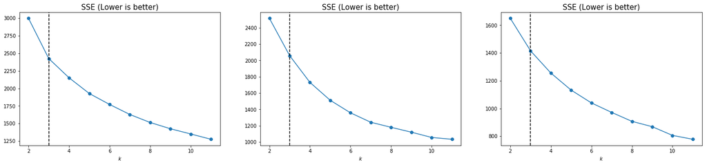

```python
plot_internal(res_X_normed20172019['inertias'], res_X_normed20002002['inertias'], res_X_normed2019['inertias']);
```

## 6. Clustering Proper

The section below discusses the clustering of players when k = 3. To determine the cluster of the actual players, the researchers appended the cluster number that was produced in the dataframe to help in separating the groups that was formed. With each player properly clustered, the most important features per cluster can be identified which will serve as the basis for extracting the theme observed in that cluster.

### 6.1. Clustering Players and Defining Clusters Formed

First, we define a function to cluster the multiple datasets that we have. Each dataset consists of the 2017-2019 combined playoffs data, 2000-2002 combined playoffs data and 2019 playoff data.

```python
def clusterer(df, df_normed, player_pos):
    # Running k-means NORMALIZED
    k = 3

    k_means = KMeans(n_clusters=k, random_state = 1337)\
                            .fit(df_normed)

    df['Cluster'] = k_means.labels_

    cluster_list = {}
    for i in range(k):
        pos = []
        cluster_list[i] = df[df['Cluster']==i]
        for x in range(len(cluster_list[i])):
            pos.append(player_pos[cluster_list[i].iloc[x].name])

        cluster_list[i]['Pos'] = pos

    # Assign each cluster to a dataframe variable
    cluster0 = cluster_list[0]
    cluster1 = cluster_list[1]
    cluster2 = cluster_list[2]

    # Creating most important features mapper per cluster
    terms = df.columns[:-1]

    feat_list = []
    for i in range(k):
        feat_list_per_cluster = []
        for ind in k_means.cluster_centers_.argsort()[:, ::-1][i, :]:
            feat_list_per_cluster.append(terms[ind])

        feat_list.append(feat_list_per_cluster)

    weight_list = np.sort(k_means.cluster_centers_)[:,::-1].tolist()

    fw_fin = []
    for i in range(len(feat_list)):
        fw = []
        for feat, weight in zip(feat_list[i], weight_list[i]):
            fw.append((feat, weight))
        fw_fin.append(fw)

    return cluster0, cluster1, cluster2, feat_list[0], feat_list[1], feat_list[2], fw_fin
```

We then run the clusterers to each dataset.

```python
# Running the clusterer on 2017-2019 Playoff data
a1, b1, c1, d1, e1, f1, fw_fin1 = clusterer(df_20172019_tocluster, df_20172019_tocluster_normed, player_pos20172019)
```

```python
# Running the clusterer on 2000-2002 Playoff data
a2, b2, c2, d2, e2, f2, fw_fin2 = clusterer(df_20002002_tocluster, df_20002002_tocluster_normed, player_pos20002002)
```

```python
# Running the clusterer on 2019 Playoff data
a3, b3, c3, d3, e3, f3, fw_fin3 = clusterer(df_2019_tocluster, df_2019_tocluster_normed, player_pos2019)
```

Using the k_means.cluster*centers* function, we can get the most important features per cluster for each dataset. The most important features for the datasets are the following:

#### 2017-2019 Playoffs

```python
print('Cluster 0 most important features are:', [fw_fin1[0][i][0] for i in range(len(fw_fin1[0]))])
print('Cluster 1 most important features are:', [fw_fin1[1][i][0] for i in range(len(fw_fin1[0]))])
print('Cluster 2 most important features are:', [fw_fin1[2][i][0] for i in range(len(fw_fin1[0]))])
```

```
Cluster 0 most important features are: ['3P%', 'BLK', 'AST', 'ORB', 'TOV', 'STL', 'DRB', 'FG%', 'PF', '2P%', 'FT%']
Cluster 1 most important features are: ['DRB', 'TOV', 'STL', 'PF', 'AST', 'BLK', 'ORB', 'FT%', 'FG%', '2P%', '3P%']
Cluster 2 most important features are: ['2P%', 'FT%', 'FG%', '3P%', 'PF', 'ORB', 'STL', 'AST', 'DRB', 'TOV', 'BLK']
```

#### 2000-2002 Playoffs

```python
print('Cluster 0 most important features are:', [fw_fin2[0][i][0] for i in range(len(fw_fin2[0]))])
print('Cluster 1 most important features are:', [fw_fin2[1][i][0] for i in range(len(fw_fin2[0]))])
print('Cluster 2 most important features are:', [fw_fin2[2][i][0] for i in range(len(fw_fin2[0]))])
```

```
Cluster 0 most important features are: ['BLK', 'AST', '3P%', 'STL', 'ORB', 'DRB', 'TOV', 'PF', 'FT%', '2P%', 'FG%']
Cluster 1 most important features are: ['2P%', 'FG%', 'FT%', '3P%', 'PF', 'ORB', 'BLK', 'STL', 'TOV', 'AST', 'DRB']
Cluster 2 most important features are: ['DRB', 'TOV', 'STL', 'AST', 'PF', 'ORB', 'BLK', 'FT%', '3P%', 'FG%', '2P%']
```

#### 2019 Playoffs

```python
print('Cluster 0 most important features are:', [fw_fin3[0][i][0] for i in range(len(fw_fin3[0]))])
print('Cluster 1 most important features are:', [fw_fin3[1][i][0] for i in range(len(fw_fin3[0]))])
print('Cluster 2 most important features are:', [fw_fin3[2][i][0] for i in range(len(fw_fin3[0]))])
```

```
Cluster 0 most important features are: ['2P%', 'FT%', 'FG%', '3P%', 'PF', 'ORB', 'STL', 'BLK', 'DRB', 'AST', 'TOV']
Cluster 1 most important features are: ['3P%', 'BLK', 'ORB', 'AST', 'STL', 'TOV', 'DRB', 'FG%', 'PF', '2P%', 'FT%']
Cluster 2 most important features are: ['DRB', 'TOV', 'PF', 'STL', 'AST', 'BLK', 'ORB', 'FT%', 'FG%', '2P%', '3P%']
```

Based on the most important features, we can see that there is not much difference between the combined stats of the last three (3) years when compared to the most recent year (2019). Players put high priority in high percentage shots and defensive rebounds.

What is interesting to note though is the difference between the playoff years of 2000-2002 with the playoff years of 2017-2019. The 2000-2002 playoffs put emphasis on blocks, 2-point percentages and defensive rebounds. This may be attributed to the fact that during the 2000s, big men or power forwards and centers were believed to be the winning formula for championships. An example of this was Shaquille O'neal's and the Los Angeles Lakers' dominance throughout these years. However, in today's game, especially in the 2017-2019 playoffs, there is emphasis on 3-point percentages which can be attributed to the rise of the Golden State Warriors and Stephen Curry.

### 6.2 Visualizing Clusters

Now let's visualize each cluster and try to see how the players were clustered for the years 2017-2019, 2000-2002 and 2019. To do this, we created a radar plot for each dataset and plotted the weight values of each feature for each cluster.

```python
# Creating a radar dataframe
def radar_plot(fw_fin):
    radar = {'cluster' : ['0', '1', '2']}
    for i in range(len(fw_fin)):
        for x in range(len(fw_fin[i])):
            if fw_fin[i][x][0] not in radar.keys():
                radar[fw_fin[i][x][0]] = [fw_fin[i][x][1]]
            else:
                radar[fw_fin[i][x][0]].append(fw_fin[i][x][1])

    df_radar = pd.DataFrame(radar)

    return df_radar
```

```python
def make_spider(fw_fin, row, title, color):

    # number of variable
    categories=list(radar_plot(fw_fin))[1:]
    N = len(categories)

    # What will be the angle of each axis in the plot? (we divide the plot / number of variable)
    angles = [n / float(N) * 2 * pi for n in range(N)]
    angles += angles[:1]

    # Initialise the spider plot
    ax = plt.subplot(1,3,row+1, polar=True, )

    # If you want the first axis to be on top:
    ax.set_theta_offset(pi / 2)
    ax.set_theta_direction(-1)

    # Draw one axe per variable + add labels labels yet
    plt.xticks(angles[:-1], categories, color='grey', size=8)

    # Draw ylabels
    ax.set_rlabel_position(0)
    plt.yticks([-1.5, -1, -0.5, 0, 0.5, 1, 1.5], ["-1.5", "-1", "0.5", "0", "0.5", "1","1.5"], color="grey", size=7)
    plt.ylim(-1.5,1.5)

    # Ind1
    values=radar_plot(fw_fin).loc[row].drop('cluster').values.flatten().tolist()
    values += values[:1]
    ax.plot(angles, values, color=color, linewidth=2, linestyle='solid')
    ax.fill(angles, values, color=color, alpha=0.4)

    # Add a title
    plt.title(title, size=11, color=color, y=1.1)
```

### 6.2.1 2017-2019 Playoffs

Shown below is the radar plot for the 2017-2019 playoffs.

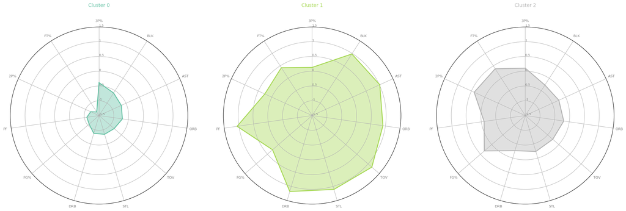

```python
# Plotting years 2017-2019

# initialize the figure
my_dpi=150
plt.figure(figsize=(25,15), dpi=my_dpi)

# Create a color palette:
my_palette = plt.cm.get_cmap("Set2", len(radar_plot(fw_fin1).index))

# Loop to plot
for row in range(0, len(radar_plot(fw_fin1).index)):
    make_spider(fw_fin1, row=row, title='Cluster '+radar_plot(fw_fin1)['cluster'][row], color=my_palette(row))
```

Choosing three (3) random players from Cluster 0, we get the following:

```python
# Cluster 0
# np.random.choice(a1.index.tolist(), 3)
```

```
array(['Jeremy Lin', 'Chris Boucher', 'Abdel Nader'], dtype='<U19')
```

These players can be thought of as players who did not play much during the playoffs. They are characterized by low percentages for all statistics on the radar plot.

Choosing three (3) random players from Cluster 1, we get the following:

```python
# np.random.choice(b1.index.tolist(), 3)
```

```
array(['Serge Ibaka', 'DeMar DeRozan', 'Donovan Mitchell'], dtype='<U23')
```

These players are the star players of the playoffs. Serge Ibaka plays for the Toronto Raptors, the current NBA champions and played a significant role in their winning. DeMar DeRozan is the star player of the San Antonio Spurs and similarly, Donovan Mitchell is the star player of the Utah Jazz. The cluster is characterized by high stats which usually suggest high playing time since they are the star players of the team.

Choosing three (3) random players from Cluster 2, we get the following:

```python
# np.random.choice(c1.index.tolist(), 3)
```

```
array(['Malcolm Delaney', 'Malcolm Brogdon', 'Danny Green'], dtype='<U23')
```

These players are the specialists/role players who are not stars but are crucial in the team's strategy. Danny Green can be seen in this group who is known to be one of the deadliest shooter / three pointer in the league. The cluster is characterized by high percentage shots based on the radar plot.

### 6.2.2 2000-2002 Playoffs

Shown below is the radar plot for the 2000-2002 playoffs.

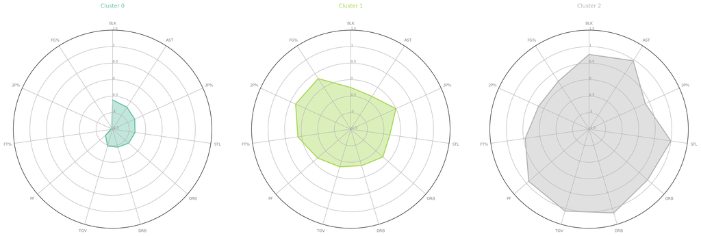

```python
# Plotting years 2000-2002

# initialize the figure
my_dpi=150
plt.figure(figsize=(25,15), dpi=my_dpi)

# Create a color palette:
my_palette = plt.cm.get_cmap("Set2", len(radar_plot(fw_fin2).index))

# Loop to plot
for row in range(0, len(radar_plot(fw_fin2).index)):
    make_spider(fw_fin2, row=row, title='Cluster '+radar_plot(fw_fin2)['cluster'][row], color=my_palette(row))
```

Choosing three (3) random players from Cluster 0, we get the following:

```python
# list(np.random.choice(a2.index.tolist(), 3))
```

```
['Alvin Jones', 'Loy Vaught', 'John Crotty']
```

Similar to the 2017-2019 playoffs, these players are characterized by low statistics. Thus these players are those that have not played much during the playoffs.

Choosing three (3) random players from Cluster 1, we get the following:

```python
# list(np.random.choice(b2.index.tolist(), 3))
```

```
['Kirk Haston', 'LaPhonso Ellis', 'William Avery']
```

These players are characterized by high percentage field goals similar to the 2017-2019 playoffs. This means that these players are the specialists/role players who play a key role in the game strategy.

Choosing three (3) random players from Cluster 2, we get the following:

```python
# list(np.random.choice(c2.index.tolist(), 3))
```

```
['Bryon Russell', 'Theo Ratliff', 'Mike Bibby']
```

These are the star players of the team, again characterized by high stats that suggest high playing time. Mike Bibby is notable as he is one of the star players of the Sacramento Kings during their playoff runs against the Los Angeles Lakers.

### 6.2.3 2019 Playoffs

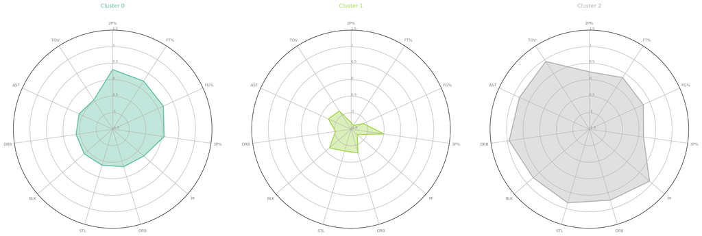

```python
# Plotting years 2019

# initialize the figure
my_dpi=150
plt.figure(figsize=(25,15), dpi=my_dpi)

# Create a color palette:
my_palette = plt.cm.get_cmap("Set2", len(radar_plot(fw_fin3).index))

# Loop to plot
for row in range(0, len(radar_plot(fw_fin3).index)):
    make_spider(fw_fin3, row=row, title='Cluster '+radar_plot(fw_fin3)['cluster'][row], color=my_palette(row))
```

Choosing three (3) random players from Cluster 0, we get the following:

```python
# list(np.random.choice(a3.index.tolist(), 3))
```

```
['Shaun Livingston', 'Jonathon Simmons', 'Seth Curry']
```

These players are the specialists/role players as seen in the radar plot. Notable players are Shaun Livingston, who is a key player for the Golden State Warriors, Seth Curry who is a decent player for the Portland Trail Blazers and Jonatahan Simmons, a decent player for the San Antonio Spurs.

Choosing three (3) random players from Cluster 1, we get the following:

```python
# list(np.random.choice(b3.index.tolist(), 3))
```

```
['Jeremy Lin', 'Langston Galloway', 'Aaron Holiday']
```

Similar to the previous datasets, these are those that have not played much during the playoffs. Jeremy Lin has not played much for the Toronto Raptors during their stint at the 2019 playoffs.

Choosing three (3) random players from Cluster 2, we get the following:

```python
list(np.random.choice(c3.index.tolist(), 3))
```

```
['Kawhi Leonard', 'Clint Capela', 'Andre Iguodala']
```

These are the star players for the 2019 playoffs. Notable players are Kawhi Leonard, the current NBA Finals MVP and NBA Champion. Clint Capela, who was instrumental in the Houston Rockets' run at the playoffs and Andre Iguodala, the former 2015 NBA Finals MVP who plays for the Golden State Warriors.

## 7. Conclusion

For the years 2017-2019, 2000-2002 and 2019, we were able to successfully cluster players according to their performance during the playoffs.

We were able to find an apparent pattern between the clusters. For each of the datasets, the three (3) clusters formed were:

1. Star players
2. Specialist / Role players
3. Players who rarely played during the playoffs

A notable finding however is the shift of importance from defense to offense when comparing the most important features for the 2000-2002 and 2017-2019 datasets. Evident in the fact that for the years 2000-2002, blocks were given more importance as opposed to the years 2017-2019, where 3P% was given more importance. This can be attributed to the fact that during the early 2000s, big men were given priority over shooters. However, in today's game, due to the rise of the Golden State Warriors and Stephen Curry, three (3) point shots were given more importance.

## 8. Recommendation

For future study, the researchers recommend to look at other decades and filter players with a certain threshold of number of games to eliminate the players that have small number of games played. They can also consider looking at the data of each player per possession or per 36 mins to better see the performance of each player.

## 9. References and Acknowledgement

To complete the study, the researchers used the following resources as reference:

https://en.wikipedia.org/wiki/National_Basketball_Association  
https://www.basketball-reference.com/

In addition to the references used in the study, the researchers would like to acknowledge their LT mates and classmates who shared some domain knowledge about NBA. Special thanks is given to Prof. Christian Alis, PhD, Prof. Erika Legara, PhD and Prof. Eduardo David, Jr. for mentoring them throughout the course and imparting their knowledge in their journey to become a Data Scientist.